# Assignment

Hennie

Sunday, June 05, 2016

# Loading and preprocessing the data

Show any code that is needed to 1. Load the data (i.e. read.csv()) 2. Process/transform the data (if necessary) into a format suitable for your analysis

```r
library(ggplot2)
#install.packages("Hmisc")
library(Hmisc)
# Clear the environment
rm(list = ls())

Activity <- read.csv("activity.csv", head = TRUE, sep = ",")
```

## Some data preparation

```r
Activity$date <- as.Date(Activity$date)
Activity$steps <- as.numeric(Activity$steps)

## Remove the NA.
ActivityWNA <- Activity[complete.cases(Activity),]
```

## Data exploration

```r
str(ActivityWNA)
```

```
## 'data.frame':    15264 obs. of  3 variables:
##  $ steps   : num  0 0 0 0 0 0 0 0 0 0 ...
##  $ date    : Date, format: "2012-10-02" "2012-10-02" ...
##  $ interval: int  0 5 10 15 20 25 30 35 40 45 ...
```

```r
dim(ActivityWNA)
```

```
## [1] 15264     3
```

```r
summary(ActivityWNA)
```

```
##      steps             date               interval
##  Min.   :  0.00   Min.   :2012-10-02   Min.   :   0.0
##  1st Qu.:  0.00   1st Qu.:2012-10-16   1st Qu.: 588.8
##  Median :  0.00   Median :2012-10-29   Median :1177.5
##  Mean   : 37.38   Mean   :2012-10-30   Mean   :1177.5
##  3rd Qu.: 12.00   3rd Qu.:2012-11-16   3rd Qu.:1766.2
##  Max.   :806.00   Max.   :2012-11-29   Max.   :2355.0
```

```r
head(ActivityWNA, 10)
```

```
##     steps       date interval
## 289     0 2012-10-02        0
## 290     0 2012-10-02        5
## 291     0 2012-10-02       10
## 292     0 2012-10-02       15
## 293     0 2012-10-02       20
## 294     0 2012-10-02       25
## 295     0 2012-10-02       30
## 296     0 2012-10-02       35
## 297     0 2012-10-02       40
## 298     0 2012-10-02       45
```

```r
names(ActivityWNA)
```

```
## [1] "steps"    "date"     "interval"
```

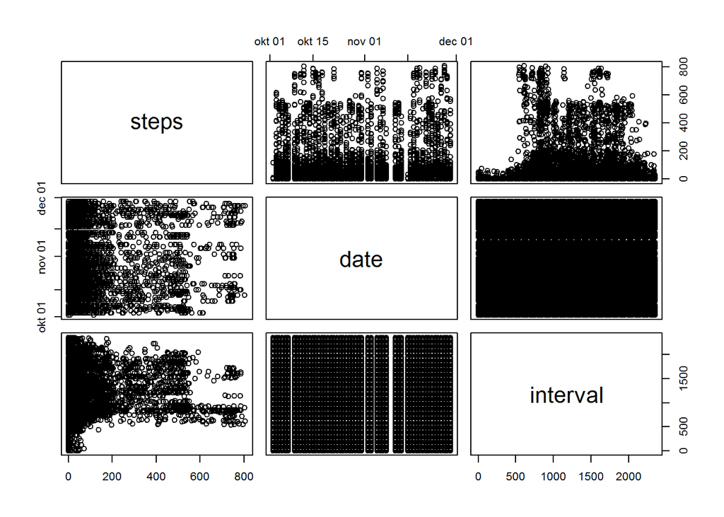

```r
pairs(ActivityWNA)
```

# What is the average daily activity pattern?

```r
ActivityWNAPerDay <- aggregate(steps ~ date, ActivityWNA, sum)

## add descriptive variable names
names(ActivityWNAPerDay)[2] <- "Sumsteps"

ActivityByDayMean <- mean(ActivityWNAPerDay$Sumsteps)
ActivityByDayMedian <- median(ActivityWNAPerDay$Sumsteps)
```

[output not shown]

[output not shown]

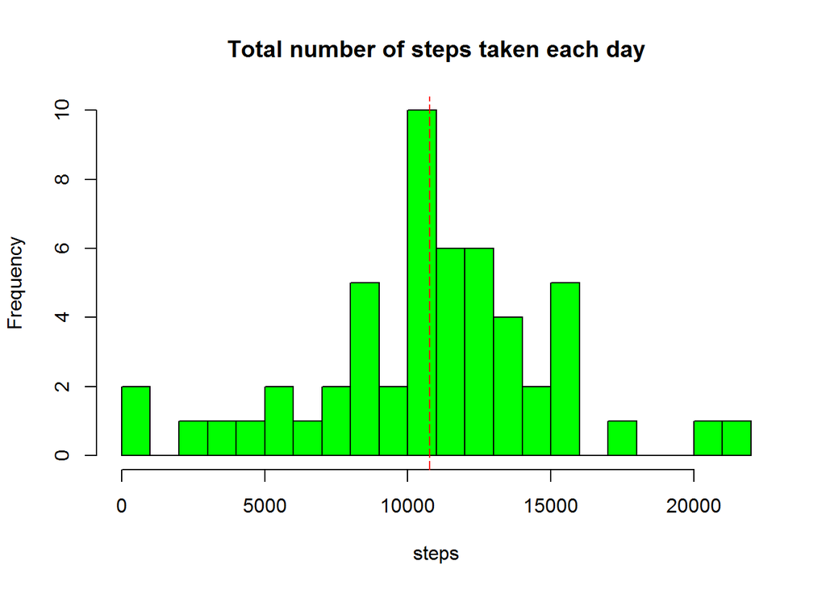

1. Make a time series plot (i.e. type = “l”) of the 5-minute interval (x-axis) and the average number of steps taken, averaged across all days (y-axis)

```r
# Make a time series plot (i.e. type = "l") of the 5-minute interval (x-axis)
# and the average number of steps taken, averaged across all days (y-axis)

ActivityWNAPerinterval <- aggregate(steps ~ interval, ActivityWNA, sum)
head(ActivityWNAPerinterval)
```

```
##   interval steps
## 1        0    91
## 2        5    18
## 3       10     7
## 4       15     8
## 5       20     4
## 6       25   111
```

[figure not shown]

```r
plot(ActivityWNAPerinterval, type = "l", col = "red",
     main ="Average number of steps interval all days",
     xlab = "Interval per 5 minutes",
     ylab = "Mean number of steps")
```

```r
# Which 5-minute interval, on average across all the days in the dataset, contains the maximum number of steps?
maxIntervalSteps <-ActivityWNAPerinterval[ActivityWNAPerinterval == max(ActivityWNAPerinterval$steps)]
ActivityWNAPerinterval[ActivityWNAPerinterval$steps == maxIntervalSteps,]
```

```
##     interval steps
## 104      835 10927
```

# Imputing missing values

Note that there are a number of days/intervals where there are missing values (coded as NA). The presence of missing days may introduce bias into some calculations or summaries of the data.

1. Calculate and report the total number of missing values in the dataset (i.e. the total number of rows with NAs)

```r
# Calculate and report the total number of missing values in the dataset (i.e. the total number of rows with NAs)
NumberOfNAs <- sum(is.na(Activity$steps))
NumberOfNAs
```

```
## [1] 2304
```

```
##    interval    steps
## 1         0 390.0608
## 2         5 317.0608
## 3        10 306.0608
## 4        15 307.0608
## 5        20 303.0608
## 6        25 410.0608
## 7        30 327.0608
## 8        35 345.0608
## 9        40 299.0608
## 10       45 377.0608
```

```
##      steps             date               interval
##  Min.   :  0.00   Min.   :2012-10-01   Min.   :   0.0
##  1st Qu.:  0.00   1st Qu.:2012-10-16   1st Qu.: 588.8
##  Median :  0.00   Median :2012-10-31   Median :1177.5
##  Mean   : 37.38   Mean   :2012-10-31   Mean   :1177.5
##  3rd Qu.: 12.00   3rd Qu.:2012-11-15   3rd Qu.:1766.2
##  Max.   :806.00   Max.   :2012-11-30   Max.   :2355.0
##  NA's   :2304
```

```
##
##  2304 values imputed to 37.3826
```

```
##      steps             date               interval
##  Min.   :  0.00   Min.   :2012-10-01   Min.   :   0.0
##  1st Qu.:  0.00   1st Qu.:2012-10-16   1st Qu.: 588.8
##  Median :  0.00   Median :2012-10-31   Median :1177.5
##  Mean   : 37.38   Mean   :2012-10-31   Mean   :1177.5
##  3rd Qu.: 37.38   3rd Qu.:2012-11-15   3rd Qu.:1766.2
##  Max.   :806.00   Max.   :2012-11-30   Max.   :2355.0
```

[figure not shown]

[figure not shown]

# Are there differences in activity patterns between weekdays and weekends?

For this part the weekdays() function may be of some help here. Use the dataset with the filled-in missing values for this part.

1. Create a new factor variable in the dataset with two levels - “weekday” and “weekend” indicating whether a given date is a weekday or weekend day.

```
##      steps       date interval  day
## 1  37.3826 2012-10-01        0 Week
## 2  37.3826 2012-10-01        5 Week
## 3  37.3826 2012-10-01       10 Week
## 4  37.3826 2012-10-01       15 Week
## 5  37.3826 2012-10-01       20 Week
## 6  37.3826 2012-10-01       25 Week
## 7  37.3826 2012-10-01       30 Week
## 8  37.3826 2012-10-01       35 Week
## 9  37.3826 2012-10-01       40 Week
## 10 37.3826 2012-10-01       45 Week
```

```
##
##  2304 values imputed to 37.3826
```

```
##      steps             date               interval          day
##  Min.   :  0.00   Min.   :2012-10-01   Min.   :   0.0   Length:17568
##  1st Qu.:  0.00   1st Qu.:2012-10-16   1st Qu.: 588.8   Class :character
##  Median :  0.00   Median :2012-10-31   Median :1177.5   Mode  :character
##  Mean   : 37.38   Mean   :2012-10-31   Mean   :1177.5
##  3rd Qu.: 37.38   3rd Qu.:2012-11-15   3rd Qu.:1766.2
##  Max.   :806.00   Max.   :2012-11-30   Max.   :2355.0
```

2. Make a panel plot containing a time series plot (i.e. type = “l”) of the 5-minute interval (x-axis) and the average number of steps taken, averaged across all weekday days or weekend days (y-axis). See the README file in the GitHub repository to see an example of what this plot should look like using simulated data.

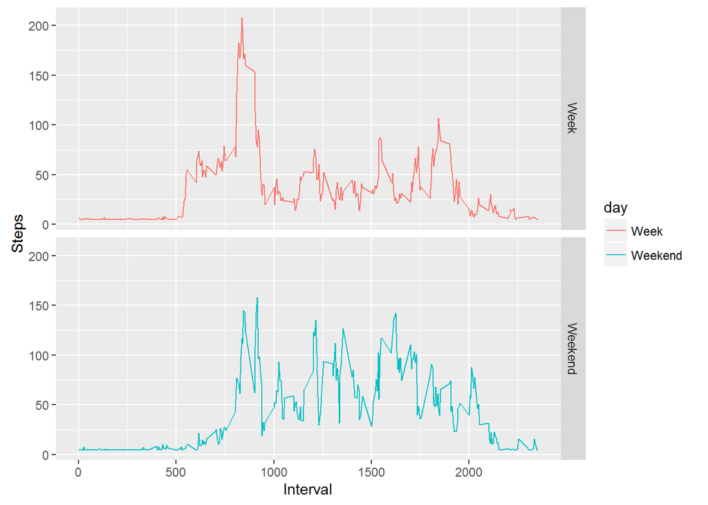